# Data Quality Check Report

Insitute for Alpine Environment, Eurac Research

Report start at **2017-12-13 12:17:46**

### INPUT info:

File selected: **M3.dat**

You have also select these parameters:

- Data start from row: *5*
- The name of column is on row: *2*
- The datetime header is: *TIMESTAMP*
- The record header is: *RECORD*
- The datetime format is: *yyyy-mm-dd HH:MM*
- The sampling interval is: *15 min*

The folders are:

- Data folder: *H:/Projekte/Klimawandel/Experiment/data/2order/DQC_BrC_test_data/*
- Report folder: *H:/Projekte/Klimawandel/Experiment/data/2order/DataQualityCheckEuracAlpEnv/Report/*
- Output folder: *H:/Projekte/Klimawandel/Experiment/data/2order/DQC_BrC_test_data/test_output/*
- Support folder: *H:/Projekte/Klimawandel/Experiment/data/2order/DataQualityCheckEuracAlpEnv/Data/Support_files/*

Range file in support folder is called: *Range.csv*

You decide: *to write output file in output folder*

### OUTPUT:

#### Info empty file:

M3.dat has some obseravtion.

#### **Duplicated rows**

More details on: H:/Projekte/Klimawandel/Experiment/data/2order/DQC_BrC_test_data/test_output/Duplicated_M3.csv

#### **Overlap**

In M3.dat there isn’t any overlap!

#### **Missing dates**

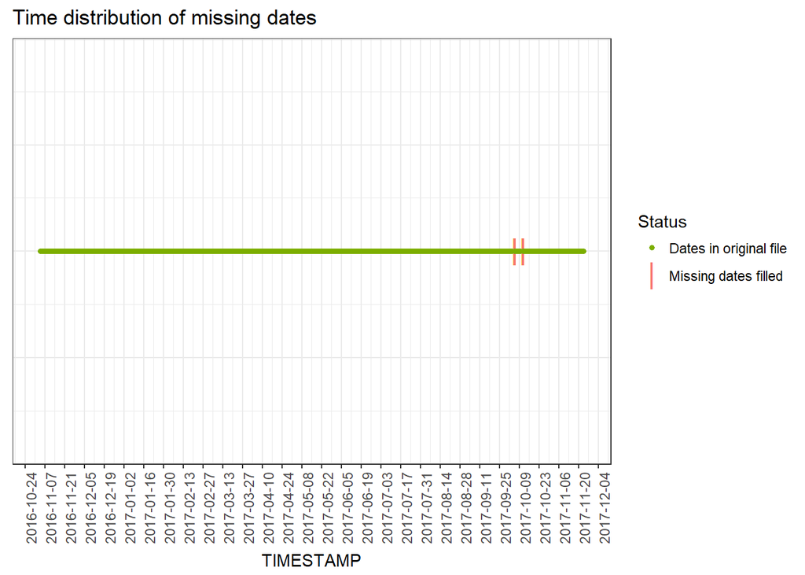

Statistics of missing dates:

| From | To | Number of Record |
| --- | --- | --- |
| 2017-10-05 13:45:00 | 2017-10-05 15:45:00 | 9 |
| 2017-10-11 13:15:00 | 2017-10-11 18:15:00 | 21 |

#### **Values out of admitted range**

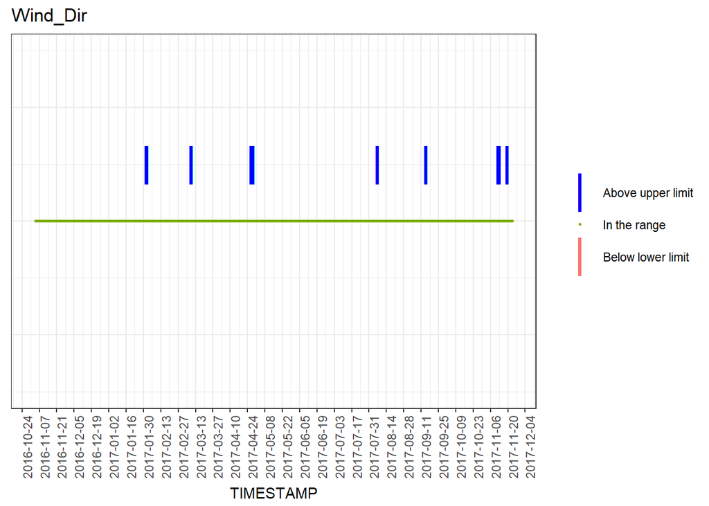

|  | From | To | Number of Record |
| --- | --- | --- | --- |
| Above upper limit | 2017-02-01 05:45:00 | 2017-02-01 09:30:00 | 16 |
| Above upper limit | 2017-03-09 04:45:00 | 2017-03-09 08:45:00 | 17 |
| Above upper limit | 2017-04-27 00:45:00 | 2017-04-27 08:00:00 | 30 |
| Above upper limit | 2017-04-28 05:30:00 | 2017-04-28 06:15:00 | 4 |
| Above upper limit | 2017-08-06 16:00:00 | 2017-08-06 16:00:00 | 1 |
| Above upper limit | 2017-09-14 17:00:00 | 2017-09-14 17:15:00 | 2 |
| Above upper limit | 2017-11-12 05:45:00 | 2017-11-12 09:15:00 | 15 |
| Above upper limit | 2017-11-12 17:30:00 | 2017-11-12 17:30:00 | 1 |
| Above upper limit | 2017-11-12 18:00:00 | 2017-11-12 18:00:00 | 1 |
| Above upper limit | 2017-11-12 18:45:00 | 2017-11-12 18:45:00 | 1 |
| Above upper limit | 2017-11-19 08:45:00 | 2017-11-19 08:45:00 | 1 |

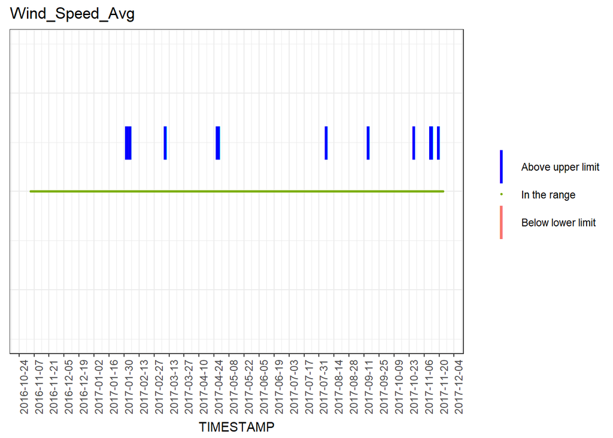

|  | From | To | Number of Record |
| --- | --- | --- | --- |
| Above upper limit | 2017-02-01 05:45:00 | 2017-02-01 09:45:00 | 17 |
| Above upper limit | 2017-02-04 08:30:00 | 2017-02-04 08:30:00 | 1 |
| Above upper limit | 2017-02-04 09:00:00 | 2017-02-04 09:00:00 | 1 |
| Above upper limit | 2017-03-09 04:30:00 | 2017-03-09 09:00:00 | 19 |
| Above upper limit | 2017-04-27 00:45:00 | 2017-04-27 08:15:00 | 31 |
| Above upper limit | 2017-04-28 05:30:00 | 2017-04-28 06:30:00 | 5 |
| Above upper limit | 2017-08-06 16:00:00 | 2017-08-06 16:15:00 | 2 |
| Above upper limit | 2017-09-14 17:00:00 | 2017-09-14 17:30:00 | 3 |
| Above upper limit | 2017-10-27 12:30:00 | 2017-10-27 12:30:00 | 1 |
| Above upper limit | 2017-11-12 05:45:00 | 2017-11-12 09:30:00 | 16 |
| Above upper limit | 2017-11-12 17:30:00 | 2017-11-12 18:15:00 | 4 |
| Above upper limit | 2017-11-12 18:45:00 | 2017-11-12 19:00:00 | 2 |
| Above upper limit | 2017-11-12 19:30:00 | 2017-11-12 20:00:00 | 3 |
| Above upper limit | 2017-11-19 08:45:00 | 2017-11-19 09:00:00 | 2 |

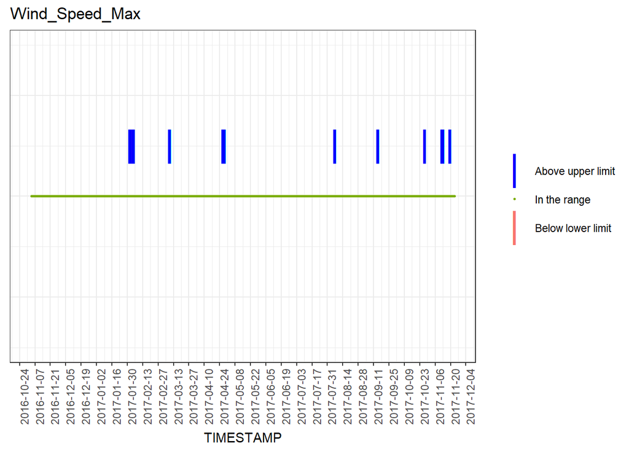

|  | From | To | Number of Record |
| --- | --- | --- | --- |
| Above upper limit | 2017-02-01 05:45:00 | 2017-02-01 09:45:00 | 17 |
| Above upper limit | 2017-02-04 08:30:00 | 2017-02-04 08:30:00 | 1 |
| Above upper limit | 2017-02-04 09:00:00 | 2017-02-04 09:00:00 | 1 |
| Above upper limit | 2017-03-09 04:30:00 | 2017-03-09 09:00:00 | 19 |
| Above upper limit | 2017-04-27 00:45:00 | 2017-04-27 08:15:00 | 31 |
| Above upper limit | 2017-04-28 05:30:00 | 2017-04-28 06:30:00 | 5 |
| Above upper limit | 2017-08-06 16:00:00 | 2017-08-06 16:15:00 | 2 |
| Above upper limit | 2017-09-14 17:00:00 | 2017-09-14 17:30:00 | 3 |
| Above upper limit | 2017-10-27 12:30:00 | 2017-10-27 12:30:00 | 1 |
| Above upper limit | 2017-11-12 05:45:00 | 2017-11-12 09:30:00 | 16 |
| Above upper limit | 2017-11-12 17:30:00 | 2017-11-12 18:15:00 | 4 |
| Above upper limit | 2017-11-12 18:45:00 | 2017-11-12 19:00:00 | 2 |
| Above upper limit | 2017-11-12 19:30:00 | 2017-11-12 20:00:00 | 3 |
| Above upper limit | 2017-11-19 08:45:00 | 2017-11-19 09:00:00 | 2 |

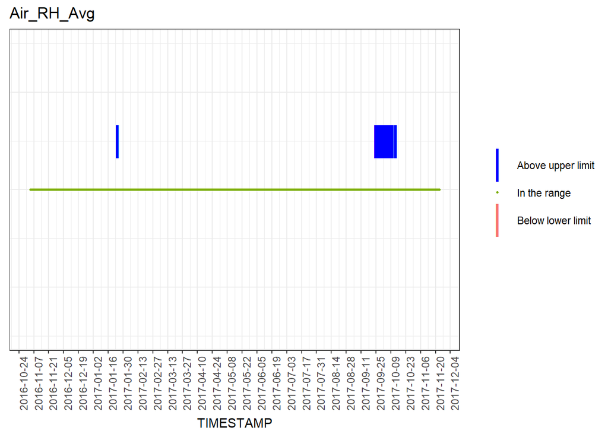

|  | From | To | Number of Record |
| --- | --- | --- | --- |
| Above upper limit | 2017-01-24 13:45:00 | 2017-01-24 14:15:00 | 3 |
| Above upper limit | 2017-09-24 18:15:00 | 2017-09-24 18:15:00 | 1 |
| Above upper limit | 2017-09-24 19:30:00 | 2017-09-24 19:30:00 | 1 |
| Above upper limit | 2017-09-25 05:00:00 | 2017-09-25 05:00:00 | 1 |
| Above upper limit | 2017-09-25 06:45:00 | 2017-09-25 07:00:00 | 2 |
| Above upper limit | 2017-09-25 16:00:00 | 2017-09-25 16:45:00 | 4 |
| Above upper limit | 2017-09-25 17:15:00 | 2017-09-25 17:15:00 | 1 |
| Above upper limit | 2017-09-25 17:45:00 | 2017-09-25 17:45:00 | 1 |
| Above upper limit | 2017-09-25 19:00:00 | 2017-09-25 20:00:00 | 5 |
| Above upper limit | 2017-09-26 00:45:00 | 2017-09-26 01:00:00 | 2 |
| Above upper limit | 2017-09-26 02:30:00 | 2017-09-26 04:15:00 | 8 |
| Above upper limit | 2017-09-26 05:15:00 | 2017-09-26 05:15:00 | 1 |
| Above upper limit | 2017-09-26 06:15:00 | 2017-09-26 07:15:00 | 5 |
| Above upper limit | 2017-09-26 08:15:00 | 2017-09-26 08:15:00 | 1 |
| Above upper limit | 2017-09-26 18:15:00 | 2017-09-26 18:15:00 | 1 |
| Above upper limit | 2017-09-26 19:00:00 | 2017-09-26 19:45:00 | 4 |
| Above upper limit | 2017-09-26 20:15:00 | 2017-09-26 20:30:00 | 2 |
| Above upper limit | 2017-09-26 21:00:00 | 2017-09-26 21:00:00 | 1 |
| Above upper limit | 2017-09-26 21:30:00 | 2017-09-26 21:30:00 | 1 |
| Above upper limit | 2017-09-26 22:00:00 | 2017-09-26 22:00:00 | 1 |
| Above upper limit | 2017-09-26 22:30:00 | 2017-09-26 22:45:00 | 2 |
| Above upper limit | 2017-09-26 23:15:00 | 2017-09-26 23:30:00 | 2 |
| Above upper limit | 2017-09-27 00:30:00 | 2017-09-27 00:45:00 | 2 |
| Above upper limit | 2017-09-27 01:30:00 | 2017-09-27 01:30:00 | 1 |
| Above upper limit | 2017-09-27 02:30:00 | 2017-09-27 02:30:00 | 1 |
| Above upper limit | 2017-09-27 03:30:00 | 2017-09-27 05:00:00 | 7 |
| Above upper limit | 2017-09-27 05:45:00 | 2017-09-27 05:45:00 | 1 |
| Above upper limit | 2017-09-27 08:45:00 | 2017-09-27 08:45:00 | 1 |
| Above upper limit | 2017-09-27 15:45:00 | 2017-09-27 16:15:00 | 3 |
| Above upper limit | 2017-09-27 16:45:00 | 2017-09-27 17:00:00 | 2 |

[output cut: 77 more lines]

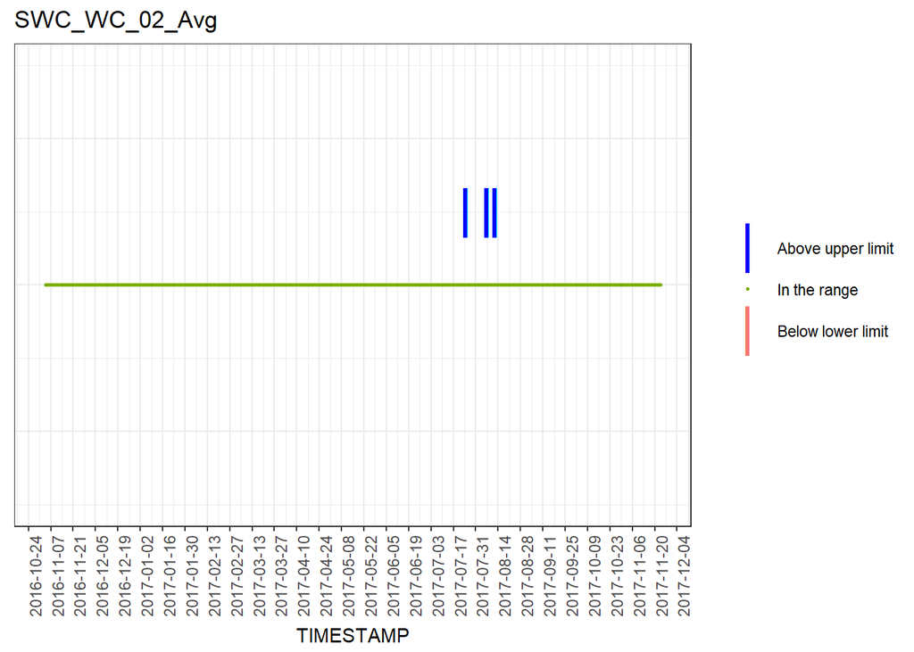

|  | From | To | Number of Record |
| --- | --- | --- | --- |
| Above upper limit | 2017-07-24 12:30:00 | 2017-07-24 13:45:00 | 6 |
| Above upper limit | 2017-08-06 12:30:00 | 2017-08-06 13:15:00 | 4 |
| Above upper limit | 2017-08-06 15:15:00 | 2017-08-06 18:00:00 | 12 |
| Above upper limit | 2017-08-11 18:00:00 | 2017-08-11 20:15:00 | 10 |

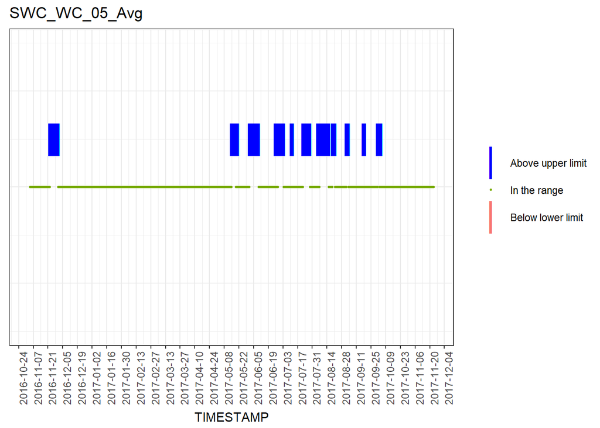

|  | From | To | Number of Record |
| --- | --- | --- | --- |
| Above upper limit | 2016-11-22 14:15:00 | 2016-11-30 12:15:00 | 761 |
| Above upper limit | 2017-05-14 17:00:00 | 2017-05-18 19:30:00 | 395 |
| Above upper limit | 2017-05-18 21:00:00 | 2017-05-19 08:45:00 | 48 |
| Above upper limit | 2017-05-19 16:15:00 | 2017-05-20 15:45:00 | 95 |
| Above upper limit | 2017-05-20 16:30:00 | 2017-05-20 16:30:00 | 1 |
| Above upper limit | 2017-05-31 19:15:00 | 2017-06-09 13:15:00 | 841 |
| Above upper limit | 2017-06-25 08:15:00 | 2017-06-25 21:15:00 | 53 |
| Above upper limit | 2017-06-28 05:00:00 | 2017-07-03 12:15:00 | 510 |
| Above upper limit | 2017-07-10 20:45:00 | 2017-07-12 00:00:00 | 110 |
| Above upper limit | 2017-07-22 01:45:00 | 2017-07-28 12:00:00 | 618 |
| Above upper limit | 2017-08-04 21:45:00 | 2017-08-05 06:15:00 | 35 |
| Above upper limit | 2017-08-06 11:15:00 | 2017-08-15 14:00:00 | 876 |
| Above upper limit | 2017-08-19 03:15:00 | 2017-08-21 15:45:00 | 243 |
| Above upper limit | 2017-09-01 08:15:00 | 2017-09-03 08:15:00 | 193 |
| Above upper limit | 2017-09-03 09:15:00 | 2017-09-03 11:30:00 | 10 |
| Above upper limit | 2017-09-17 13:30:00 | 2017-09-18 06:15:00 | 68 |
| Above upper limit | 2017-09-18 10:15:00 | 2017-09-18 20:15:00 | 41 |
| Above upper limit | 2017-09-30 19:00:00 | 2017-10-02 13:45:00 | 172 |
| Above upper limit | 2017-10-03 12:15:00 | 2017-10-04 12:45:00 | 99 |

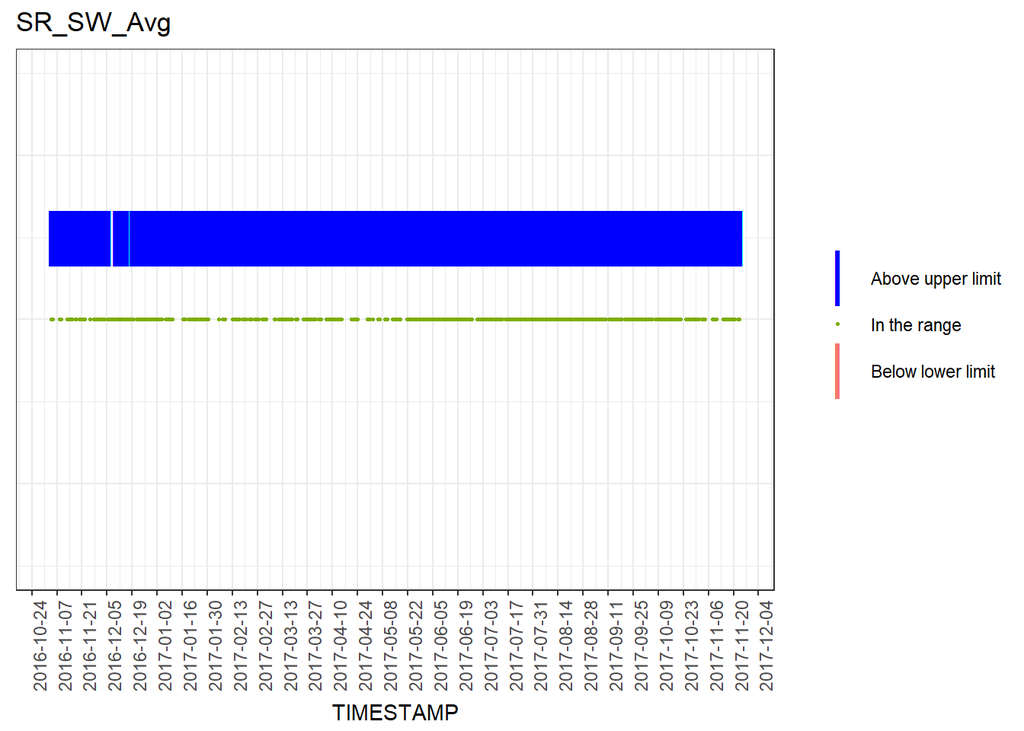

|  | From | To | Number of Record |
| --- | --- | --- | --- |
| Above upper limit | 2016-11-03 16:00:00 | 2016-11-04 12:15:00 | 82 |
| Above upper limit | 2016-11-04 12:45:00 | 2016-11-08 11:00:00 | 378 |
| Above upper limit | 2016-11-08 14:00:00 | 2016-11-09 09:00:00 | 77 |
| Above upper limit | 2016-11-09 10:15:00 | 2016-11-09 11:00:00 | 4 |
| Above upper limit | 2016-11-09 11:45:00 | 2016-11-12 11:45:00 | 289 |
| Above upper limit | 2016-11-12 12:15:00 | 2016-11-12 12:15:00 | 1 |
| Above upper limit | 2016-11-12 14:45:00 | 2016-11-12 22:30:00 | 32 |
| Above upper limit | 2016-11-13 12:15:00 | 2016-11-14 11:30:00 | 94 |
| Above upper limit | 2016-11-14 15:00:00 | 2016-11-14 22:45:00 | 32 |
| Above upper limit | 2016-11-15 09:30:00 | 2016-11-15 09:30:00 | 1 |
| Above upper limit | 2016-11-15 10:00:00 | 2016-11-15 10:00:00 | 1 |
| Above upper limit | 2016-11-15 10:30:00 | 2016-11-15 11:30:00 | 5 |
| Above upper limit | 2016-11-15 15:45:00 | 2016-11-17 12:15:00 | 179 |
| Above upper limit | 2016-11-17 15:15:00 | 2016-11-19 12:00:00 | 180 |
| Above upper limit | 2016-11-19 12:30:00 | 2016-11-20 02:15:00 | 56 |
| Above upper limit | 2016-11-20 02:45:00 | 2016-11-20 12:45:00 | 41 |
| Above upper limit | 2016-11-20 13:15:00 | 2016-11-21 11:00:00 | 88 |
| Above upper limit | 2016-11-21 12:15:00 | 2016-11-21 12:15:00 | 1 |
| Above upper limit | 2016-11-21 15:00:00 | 2016-11-22 12:15:00 | 86 |
| Above upper limit | 2016-11-22 13:00:00 | 2016-11-25 11:00:00 | 281 |
| Above upper limit | 2016-11-25 11:45:00 | 2016-11-27 11:00:00 | 190 |
| Above upper limit | 2016-11-27 15:15:00 | 2016-11-28 11:00:00 | 80 |
| Above upper limit | 2016-11-28 15:15:00 | 2016-11-28 19:00:00 | 16 |
| Above upper limit | 2016-11-28 19:30:00 | 2016-11-28 21:15:00 | 8 |
| Above upper limit | 2016-11-28 22:15:00 | 2016-11-29 01:30:00 | 14 |
| Above upper limit | 2016-11-29 02:00:00 | 2016-11-29 02:00:00 | 1 |
| Above upper limit | 2016-11-29 04:30:00 | 2016-11-29 04:45:00 | 2 |
| Above upper limit | 2016-11-29 05:15:00 | 2016-11-29 05:30:00 | 2 |
| Above upper limit | 2016-11-29 06:00:00 | 2016-11-29 07:45:00 | 8 |
| Above upper limit | 2016-11-29 08:15:00 | 2016-11-29 08:30:00 | 2 |

[output cut: 572 more lines]

Report end at **2017-12-13 12:19:12**